# AlexanderNg_A8

Alexander Ng

11/12/2021

Brentwood & Oakley Cities PUMA relative to Antioch BART station.

[interactive chart not shown]

Control PUMAs matched with Brentwood & Oakley PUMA.

[interactive chart not shown]

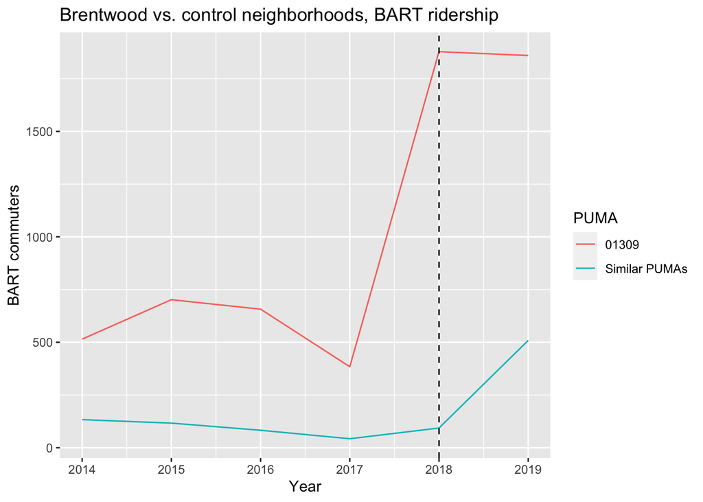

```
##
## Call:
## lm(formula = bart ~ treated * time, data = transit_did)
##
## Residuals:
##     Min      1Q  Median      3Q     Max
## -301.10  -93.83  -53.30   64.68 1135.90
##
## Coefficients:
##              Estimate Std. Error t value Pr(>|t|)
## (Intercept)     93.82      36.51   2.570  0.01259 *
## treated        470.68     121.08   3.887  0.00025 ***
## time           207.28      63.23   3.278  0.00172 **
## treated:time  1097.22     209.72   5.232 2.11e-06 ***
## ---
## Signif. codes:  0 '***' 0.001 '**' 0.01 '*' 0.05 '.' 0.1 ' ' 1
##
## Residual standard error: 230.9 on 62 degrees of freedom
## Multiple R-squared:  0.6682, Adjusted R-squared:  0.6522
## F-statistic: 41.63 on 3 and 62 DF,  p-value: 7.327e-15
```

#Replicate Weights

```
##    rowname               base            stderror
##  Length:4           Min.   :  93.83   Min.   :4.263e-13
##  Class :character   1st Qu.: 178.91   1st Qu.:4.476e-13
##  Mode  :character   Median : 338.98   Median :2.956e-12
##                     Mean   : 467.25   Mean   :3.148e-12
##                     3rd Qu.: 627.31   3rd Qu.:5.656e-12
##                     Max.   :1097.22   Max.   :6.253e-12
```

# Comments on Model

It appears that the opening of Antioch Station resulted in a direct increase of 1097 BART commuters in Brentwood. This result appears to be of statistical significance as the p-value is < 5%. The initial adjusted r-square value of 0.6522 and standard error of 209.72 suggest that the chosen model under current constraints may not represent the best fit for the available data. However, after accounting for replicate weights the standard error has reduced significantly to being almost negligible (order of negative 12). Accounting for replicate weights has produced a more representative portrayal of the causal relation in ridership numbers between BART commuters in Brentwood due to Antioch Station against the control PUMAs.

Key notes on the analysis parameters:

1. Model above evaluates bart ridership departing from Brentwood, which may not be the most accurate measure to evaluate the effect of Antioch Station. In addition, the PUMAs data registers commuters who use BART for work trips and does not account for non-work trips.
2. Model above evaluates data over a 5 year period between 2014-2019. Ridership on new transit developments are typically characterized by modest increase in ridership initially and higher increases in the subsequent years as other developments (i.e. housing/commercial) mature within the vicinity of the transit development. As Antioch Station turned operational in 2018, an analysis of ridership levels at Brentwood over a longer duration post construction would be more representative of the analysis.
3. Apart from train ridership, no other control variables were used to identify matching PUMAs. This may have a limiting effect over the study.